# Lab 5

Random Forests/Bagging

Stephanie Gluck

11/23/2020

## Data

Read in the `train.csv` data.

- Because some of the models will take some time run, randomly sample 1% of the data (be sure to use `set.seed`).
- Remove the *classification* variable.

Read in the `fallmembershipreport_20192020.xlsx` data.

- Select `Attending School ID`, `School Name`, and all columns that represent the race/ethnicity percentages for the schools (there is example code in recent class slides).

Join the two data sets.

If you have accessed outside data to help increase the performance of your models for the final project (e.g., [NCES](https://nces.ed.gov/)), you can read in and join those data as well.

```r
data <- rio::import("data/data.csv")
data_sub <- data %>%
  sample_frac(.01)
```

## Split and Resample

Split joined data from above into a training set and test set, stratified by the outcome `score`.

Use 10-fold CV to resample the training set, stratified by `score`.

```r
set.seed(3000)

splits <- initial_split(data_sub, strata = "score")
train <- training(splits)
test <- testing(splits)
cv_splits <- vfold_cv(train, stata = "score")
```

## Preprocess

Create one `recipe` to prepare your data for CART, bagged tree, and random forest models.

This lab could potentially serve as a template for your **Premilinary Fit 2**, or your final model prediction for the **Final Project**, so consider applying what might be your best model formula and the necessary preprocessing steps.

```r
rec <- recipe(score ~ ., train) %>%
    step_mutate(tst_dt = lubridate::mdy_hm(tst_dt)) %>%
    update_role(contains("id"), ncessch, sch_name, new_role = "id vars") %>%
    step_novel(all_nominal()) %>%
    step_unknown(all_nominal()) %>%
    step_nzv(all_predictors(), freq_cut = 99/1) %>%
    step_normalize(all_numeric(), -all_outcomes(), -has_role("id vars")) %>%
    step_BoxCox(all_numeric(), -all_outcomes(), -has_role("id vars")) %>%
    step_medianimpute(all_numeric(), -all_outcomes(), -has_role("id vars")) %>%
    step_dummy(all_nominal(), -has_role("id vars"), one_hot = TRUE) %>%
    step_zv(all_predictors())

rec
```

```
## Data Recipe
##
## Inputs:
##
##       role #variables
##    id vars          7
##    outcome          1
##  predictor         45
##
## Operations:
##
## Variable mutation for tst_dt
## Novel factor level assignment for all_nominal()
## Unknown factor level assignment for all_nominal()
## Sparse, unbalanced variable filter on all_predictors()
## Centering and scaling for all_numeric(), ...
## Box-Cox transformation on all_numeric(), ...
## Median Imputation for all_numeric(), ...
## Dummy variables from all_nominal(), -has_role("id vars")
## Zero variance filter on all_predictors()
```

```r
temp <- prep(rec)

tidy(temp)
```

```
## # A tibble: 9 x 6
##   number operation type         trained skip  id
##    <int> <chr>     <chr>        <lgl>   <lgl> <chr>
## 1      1 step      mutate       TRUE    FALSE mutate_PU8aD
## 2      2 step      novel        TRUE    FALSE novel_RRR5w
## 3      3 step      unknown      TRUE    FALSE unknown_VJ544
## 4      4 step      nzv          TRUE    FALSE nzv_jWIsi
## 5      5 step      normalize    TRUE    FALSE normalize_ZMPKk
## 6      6 step      BoxCox       TRUE    FALSE BoxCox_1ojdJ
## 7      7 step      medianimpute TRUE    FALSE medianimpute_o2Qwk
## 8      8 step      dummy        TRUE    FALSE dummy_jNgzP
## 9      9 step      zv           TRUE    FALSE zv_qZk9e
```

```r
#novel
tidy(temp, 2) %>%
  print(n = Inf)
```

```
## # A tibble: 31 x 3
##    terms               value id
##    <chr>               <chr> <chr>
##  1 gndr                new   novel_RRR5w
##  2 ethnic_cd           new   novel_RRR5w
##  3 tst_bnch            new   novel_RRR5w
##  4 migrant_ed_fg       new   novel_RRR5w
##  5 ind_ed_fg           new   novel_RRR5w
##  6 sp_ed_fg            new   novel_RRR5w
##  7 tag_ed_fg           new   novel_RRR5w
##  8 econ_dsvntg         new   novel_RRR5w
##  9 ayp_lep             new   novel_RRR5w
## 10 stay_in_dist        new   novel_RRR5w
## 11 stay_in_schl        new   novel_RRR5w
## 12 dist_sped           new   novel_RRR5w
```

[output cut: 19 more lines]

```r
#unknown
tidy(temp, 3) %>%
  print(n = Inf)
```

```
## # A tibble: 31 x 3
##    terms               value   id
##    <chr>               <chr>   <chr>
##  1 gndr                unknown unknown_VJ544
##  2 ethnic_cd           unknown unknown_VJ544
##  3 tst_bnch            unknown unknown_VJ544
##  4 migrant_ed_fg       unknown unknown_VJ544
##  5 ind_ed_fg           unknown unknown_VJ544
##  6 sp_ed_fg            unknown unknown_VJ544
##  7 tag_ed_fg           unknown unknown_VJ544
##  8 econ_dsvntg         unknown unknown_VJ544
##  9 ayp_lep             unknown unknown_VJ544
## 10 stay_in_dist        unknown unknown_VJ544
## 11 stay_in_schl        unknown unknown_VJ544
## 12 dist_sped           unknown unknown_VJ544
```

[output cut: 19 more lines]

```r
#nzv
tidy(temp, 4) %>%
  print(n = Inf)
```

```
## # A tibble: 11 x 2
##    terms               id
##    <chr>               <chr>
##  1 calc_admn_cd        nzv_jWIsi
##  2 ind_ed_fg           nzv_jWIsi
##  3 dist_sped           nzv_jWIsi
##  4 ayp_dist_partic     nzv_jWIsi
##  5 ayp_schl_partic     nzv_jWIsi
##  6 rc_dist_partic      nzv_jWIsi
##  7 rc_schl_partic      nzv_jWIsi
##  8 tst_atmpt_fg        nzv_jWIsi
##  9 grp_rpt_dist_partic nzv_jWIsi
## 10 grp_rpt_schl_partic nzv_jWIsi
## 11 grp_rpt_dist_prfrm  nzv_jWIsi
```

## Decision Tree

1. Create a `parsnip` CART model using`{rpart}` for the estimation, tuning the cost complexity and minimum $n$ for a terminal node.

```r
dt_tune_mod <- decision_tree() %>%
  set_mode("regression") %>%
  set_engine("rpart") %>%
  set_args(cost_complexity = tune(),
           min_n = tune())
```

2. Create a `workflow` object that combines your `recipe` and your `parsnip` objects.

```r
dt_tune_workflow <- workflow() %>%
  add_recipe(rec) %>%
  add_model(dt_tune_mod)
```

3. Tune your model with `tune_grid`
- Use `grid = 10` to choose 10 grid points automatically
- In the `metrics` argument, please include `rmse`, `rsq`, and `huber_loss`
- Record the time it takes to run. You could use `{tictoc}`, or you could do something like:

```r
start_rf <- Sys.time()

dt_tune_fit <- tune_grid(
  dt_tune_workflow,
  cv_splits,
  grid = 10,
  metrics = yardstick::metric_set(rmse, rsq, huber_loss),
  control = tune::control_resamples(verbose = FALSE, #turn off for knitted doc
                                    save_pred = TRUE))

end_rf <- Sys.time()
(dt_time <- end_rf - start_rf)
```

```
## Time difference of 57.4143 secs
```

4. Show the best estimates for each of the three performance metrics and the tuning parameter values associated with each.

```r
dt_tune_fit %>%
  collect_metrics(summarize = FALSE)
```

```
## # A tibble: 300 x 7
##    id     cost_complexity min_n .metric    .estimator .estimate .config
##    <chr>            <dbl> <int> <chr>      <chr>          <dbl> <chr>
##  1 Fold01   0.0116           23 rmse       standard      86.1   Model01
##  2 Fold01   0.0116           23 rsq        standard       0.315 Model01
##  3 Fold01   0.0116           23 huber_loss standard      69.6   Model01
##  4 Fold01   0.0000000621     30 rmse       standard      88.9   Model02
##  5 Fold01   0.0000000621     30 rsq        standard       0.333 Model02
##  6 Fold01   0.0000000621     30 huber_loss standard      69.9   Model02
##  7 Fold01   0.00000000373    36 rmse       standard      90.7   Model03
##  8 Fold01   0.00000000373    36 rsq        standard       0.315 Model03
##  9 Fold01   0.00000000373    36 huber_loss standard      71.3   Model03
## 10 Fold01   0.0000862        12 rmse       standard      97.1   Model04
## # ... with 290 more rows
```

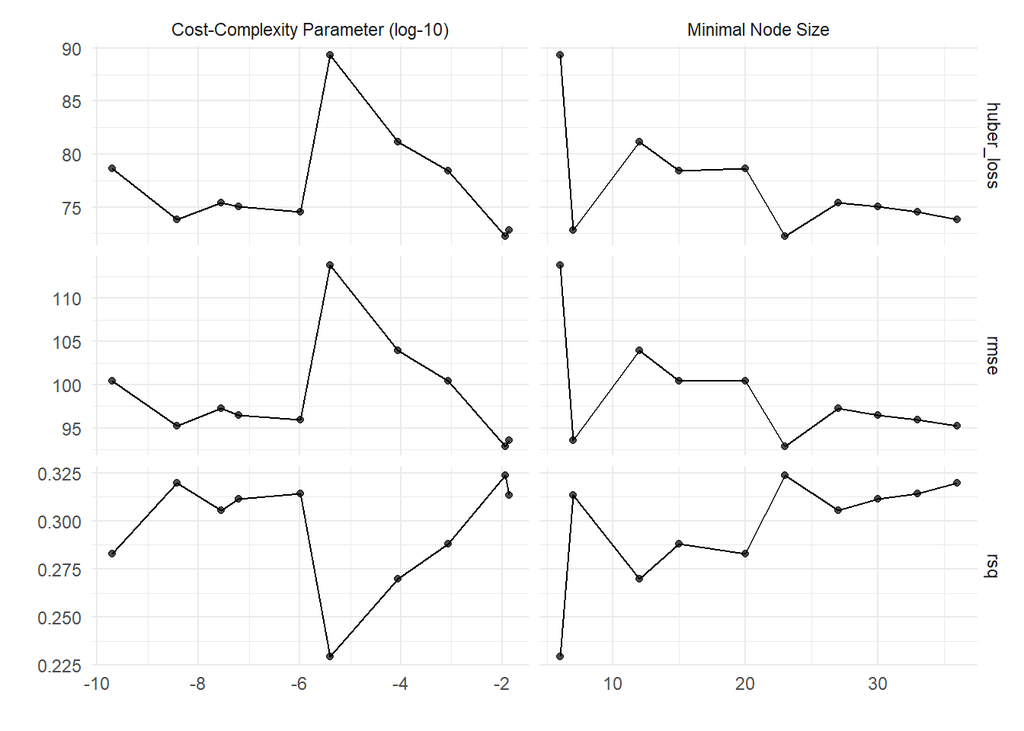

```r
dt_tune_fit %>%
  autoplot() +
  geom_line()
```

```r
show_best(dt_tune_fit, metric = "rmse", n = 1)
```

```
## # A tibble: 1 x 8
##   cost_complexity min_n .metric .estimator  mean     n std_err .config
##             <dbl> <int> <chr>   <chr>      <dbl> <int>   <dbl> <chr>
## 1          0.0116    23 rmse    standard    92.9    10    1.21 Model01
```

```r
show_best(dt_tune_fit, metric = "rsq", n = 1)
```

```
## # A tibble: 1 x 8
##   cost_complexity min_n .metric .estimator  mean     n std_err .config
##             <dbl> <int> <chr>   <chr>      <dbl> <int>   <dbl> <chr>
## 1          0.0116    23 rsq     standard   0.324    10  0.0205 Model01
```

```r
show_best(dt_tune_fit, metric = "huber_loss", n = 1)
```

```
## # A tibble: 1 x 8
##   cost_complexity min_n .metric    .estimator  mean     n std_err .config
##             <dbl> <int> <chr>      <chr>      <dbl> <int>   <dbl> <chr>
## 1          0.0116    23 huber_loss standard    72.2    10    1.36 Model01
```

## Bagged Tree

1. Create a `parsnip` bagged tree model using`{baguette}`
- specify 10 bootstrap resamples (only to keep run-time down), and
- tune on `cost_complexity` and `min_n`

```r
bt_mod <- bag_tree() %>%
  set_mode("regression") %>%
  set_engine("rpart", times = 10) %>% # 10 bootstrap re-samples
  set_args(cost_complexity = tune(),
           min_n = tune())
```

2. Create a `workflow` object that combines your `recipe` and your bagged tree model specification.

```r
bt_tune_workflow <- workflow() %>%
  add_recipe(rec) %>%
  add_model(bt_mod)
```

3. Tune your model with `tune_grid`
- Use `grid = 10` to choose 10 grid points automatically
- In the `metrics` argument, please include `rmse`, `rsq`, and `huber_loss`
- In the `control` argument, please include `extract = function(x) extract_model(x)` to extract the model from each fit
- `{baguette}` is optimized to run in parallel with the `{future}` package. Consider using `{future}` to speed up processing time (see the class slides)
- Record the time it takes to run

#### **Question: Before you run the code, how many trees will this function execute?**

1,000 trees (10 folds * 10 grids * 10 models)

```r
plan(multisession)

start_rf <- Sys.time()

bt_tune_fit <- tune_grid(
  bt_tune_workflow,
  cv_splits,
  grid = 10,
  metrics = yardstick::metric_set(rmse, rsq, huber_loss),
  control = control_resamples(verbose   = FALSE, #turn off for knitted doc
                              save_pred = TRUE,
                              extract = function(x) extract_model(x)))

end_rf <- Sys.time()
(bt_time <- end_rf - start_rf)
```

```
## Time difference of 3.580816 mins
```

```r
plan(sequential)
```

4. Show the single best estimates for each of the three performance metrics and the tuning parameter values associated with each.

```r
bt_tune_fit %>%
  collect_metrics(summarize = FALSE)
```

```
## # A tibble: 300 x 7
##    id     cost_complexity min_n .metric    .estimator .estimate .config
##    <chr>            <dbl> <int> <chr>      <chr>          <dbl> <chr>
##  1 Fold01     0.00000438     37 rmse       standard      81.2   Model01
##  2 Fold01     0.00000438     37 rsq        standard       0.401 Model01
##  3 Fold01     0.00000438     37 huber_loss standard      63.9   Model01
##  4 Fold01     0.000000130    33 rmse       standard      82.2   Model02
##  5 Fold01     0.000000130    33 rsq        standard       0.385 Model02
##  6 Fold01     0.000000130    33 huber_loss standard      65.4   Model02
##  7 Fold01     0.00286        13 rmse       standard      84.1   Model03
##  8 Fold01     0.00286        13 rsq        standard       0.362 Model03
##  9 Fold01     0.00286        13 huber_loss standard      66.7   Model03
## 10 Fold01     0.00000160     14 rmse       standard      83.5   Model04
## # ... with 290 more rows
```

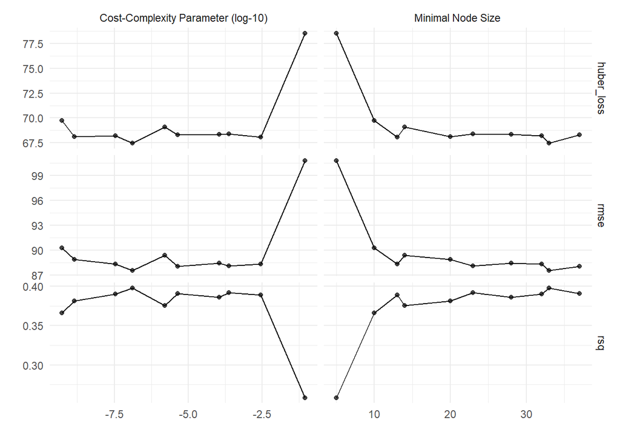

```r
bt_tune_fit %>%
  autoplot() +
  geom_line()
```

```r
show_best(bt_tune_fit, metric = "rmse", n = 1)
```

```
## # A tibble: 1 x 8
##   cost_complexity min_n .metric .estimator  mean     n std_err .config
##             <dbl> <int> <chr>   <chr>      <dbl> <int>   <dbl> <chr>
## 1     0.000000130    33 rmse    standard    87.6    10    1.16 Model02
```

```r
show_best(bt_tune_fit, metric = "rsq", n = 1)
```

```
## # A tibble: 1 x 8
##   cost_complexity min_n .metric .estimator  mean     n std_err .config
##             <dbl> <int> <chr>   <chr>      <dbl> <int>   <dbl> <chr>
## 1     0.000000130    33 rsq     standard   0.398    10  0.0203 Model02
```

```r
show_best(bt_tune_fit, metric = "huber_loss", n = 1)
```

```
## # A tibble: 1 x 8
##   cost_complexity min_n .metric    .estimator  mean     n std_err .config
##             <dbl> <int> <chr>      <chr>      <dbl> <int>   <dbl> <chr>
## 1     0.000000130    33 huber_loss standard    67.5    10    1.34 Model02
```

5. Run the `bag_roots` function below. Apply this function to the extracted bagged tree models from the previous step. This will output the feature at the root node for each of the decision trees fit.

```r
bag_roots <- function(x){
  x %>%
  select(.extracts) %>%
  unnest(cols = c(.extracts)) %>%
  mutate(models = map(.extracts,
                  ~.x$model_df)) %>%
  select(-.extracts) %>%
  unnest(cols = c(models)) %>%
  mutate(root = map_chr(model,
                     ~as.character(.x$fit$frame[1, 1]))) %>%
  select(root)
}

bt_roots <- bag_roots(bt_tune_fit)
```

6. Produce a plot of the frequency of features at the root node of the trees in your bagged model.

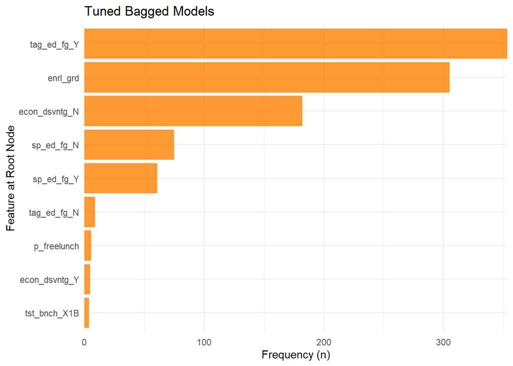

```r
bt_roots %>%
  group_by(root) %>%
  count() %>%
  ggplot(aes(n, reorder(root, n))) +
  geom_col(fill = "darkorange1",
           alpha = .80) +
  labs(y = "Feature at Root Node",
       x = "Frequency (n)",
       title = "Tuned Bagged Models") +
  scale_x_continuous(expand = c(0, 0))
```

## Random Forest

1. Create a `parsnip` random forest model using `{ranger}`
- use the `importance = "permutation"` argument to run variable importance
- specify 1,000 trees, but keep the other default tuning parameters

```r
cores <- parallel::detectCores()

rf_tune_mod <- rand_forest() %>%
  set_engine("ranger",
             num.threads = cores,
             importance = "permutation",
             verbose = TRUE) %>%
  set_mode("regression") %>%
  set_args(mtry = tune(),
           trees = 1000,
           min_n = tune())
```

2. Create a `workflow` object that combines your `recipe` and your random forest model specification.

```r
rf_tune_workflow <- workflow() %>%
  add_recipe(rec) %>%
  add_model(rf_tune_mod)
```

3. Fit your model
- In the `metrics` argument, please include `rmse`, `rsq`, and `huber_loss`
- In the `control` argument, please include `extract = function(x) x` to extract the workflow from each fit
- Record the time it takes to run

```r
start_rf <- Sys.time()

rf_tune_fit <- tune_grid(
  rf_tune_workflow,
  cv_splits,
  metrics = yardstick::metric_set(rmse, rsq, huber_loss),
  control = control_resamples(verbose = FALSE, #turn off for knitted doc
                              save_pred = TRUE,
                              extract = function(x) x)
)

end_rf <- Sys.time()
(rf_time <- end_rf - start_rf)
```

```
## Time difference of 4.3 mins
```

4. Show the single best estimates for each of the three performance metrics.

```r
rf_tune_fit %>%
  collect_metrics(summarize = FALSE)
```

```
## # A tibble: 300 x 7
##    id      mtry min_n .metric    .estimator .estimate .config
##    <chr>  <int> <int> <chr>      <chr>          <dbl> <chr>
##  1 Fold01    24    38 rmse       standard      79.9   Model01
##  2 Fold01    24    38 rsq        standard       0.411 Model01
##  3 Fold01    24    38 huber_loss standard      63.7   Model01
##  4 Fold01    75    31 rmse       standard      80.3   Model02
##  5 Fold01    75    31 rsq        standard       0.412 Model02
##  6 Fold01    75    31 huber_loss standard      63.9   Model02
##  7 Fold01    76    18 rmse       standard      80.6   Model03
##  8 Fold01    76    18 rsq        standard       0.413 Model03
##  9 Fold01    76    18 huber_loss standard      64.2   Model03
## 10 Fold01    28     8 rmse       standard      80.0   Model04
## # ... with 290 more rows
```

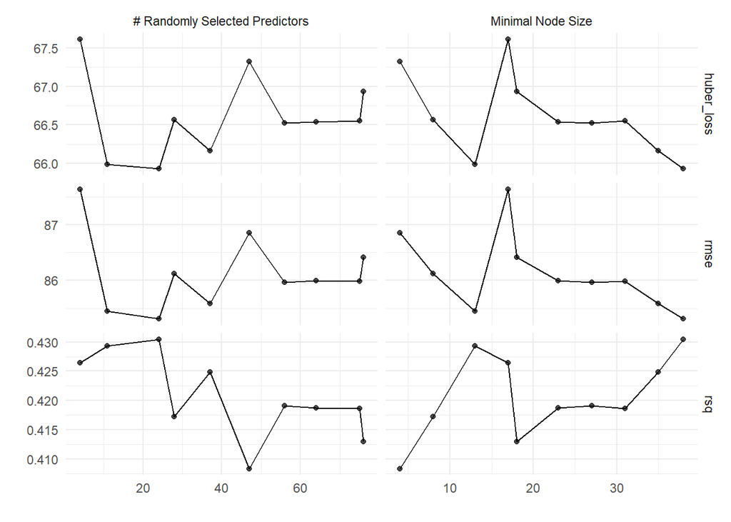

```r
rf_tune_fit %>%
  autoplot() +
  geom_line()
```

```r
show_best(rf_tune_fit, metric = "rmse", n = 1)
```

```
## # A tibble: 1 x 8
##    mtry min_n .metric .estimator  mean     n std_err .config
##   <int> <int> <chr>   <chr>      <dbl> <int>   <dbl> <chr>
## 1    24    38 rmse    standard    85.3    10    1.11 Model01
```

```r
show_best(rf_tune_fit, metric = "rsq", n = 1)
```

```
## # A tibble: 1 x 8
##    mtry min_n .metric .estimator  mean     n std_err .config
##   <int> <int> <chr>   <chr>      <dbl> <int>   <dbl> <chr>
## 1    24    38 rsq     standard   0.430    10  0.0233 Model01
```

```r
show_best(rf_tune_fit, metric = "huber_loss", n = 1)
```

```
## # A tibble: 1 x 8
##    mtry min_n .metric    .estimator  mean     n std_err .config
##   <int> <int> <chr>      <chr>      <dbl> <int>   <dbl> <chr>
## 1    24    38 huber_loss standard    65.9    10    1.23 Model01
```

5. Run the two functions in the code chunk below. Then apply the `rf_roots` function to the results of your random forest model to output the feature at the root node for each of the decision trees fit in your random forest model.

```r
rf_tree_roots <- function(x){
  map_chr(1:1000,
           ~ranger::treeInfo(x, tree = .)[1, "splitvarName"])
}

rf_roots <- function(x){
  x %>%
  select(.extracts) %>%
  unnest(cols = c(.extracts)) %>%
  mutate(fit = map(.extracts,
                   ~.x$fit$fit$fit),
         oob_rmse = map_dbl(fit,
                         ~sqrt(.x$prediction.error)),
         roots = map(fit,
                        ~rf_tree_roots(.))
         ) %>%
  select(roots) %>%
  unnest(cols = c(roots))
}

rf_roots_tbl <- rf_roots(rf_tune_fit)
```

6. Produce a plot of the frequency of features at the root node of the trees in your bagged model.

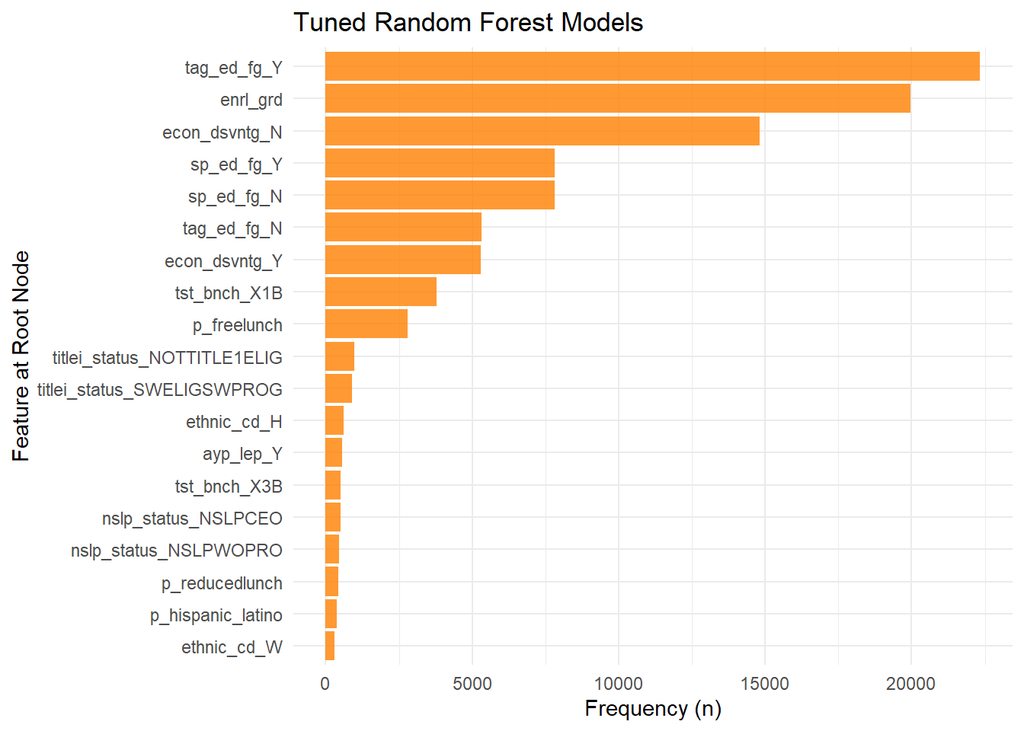

```r
rf_roots_tbl %>%
  group_by(roots) %>%
  count() %>%
  filter(n > 300) %>% # to get only the most common count
  ggplot(aes(n, reorder(roots, n))) +
  geom_col(fill = "darkorange1",
           alpha = .8) +
  labs(y = "Feature at Root Node",
       x = "Frequency (n)",
       title = "Tuned Random Forest Models")
```

7. Please explain why the bagged tree root node figure and the random forest root node figure are different.

**Bagged tree** generally split at variables with the strongest prediction to the outcome variable which results in very similar initial split at the top of the tree. When strong predictors are present, the strong predictors will drive the initial split which decreases the variability of subsequent splits and make tress from different resamples highly correlated to one another.

**Random forest** decreases the correlation between different tree resamples by restricting splits to a random subset of the original predictors (mtry) which increases the variability of each tree leading to a more precise aggregated prediction.

8. Apply the `fit` function to your random forest `workflow` object and your **full** training data. In class we talked about the idea that bagged tree and random forest models use resampling, and one *could* use the OOB prediction error provided by the models to estimate model performance.
- Record the time it takes to run
- Extract the oob prediction error from your fitted object. If you print your fitted object, you will see a value for *OOB prediction error (MSE)*. You can take the `sqrt()` of this value to get the *rmse*. Or you can extract it by running: `sqrt(fit-object-name-here$fit$fit$fit$prediction.error)`.

```r
#model used in the workflow
# rf_tune_mod <- rand_forest() %>%
#   set_engine("ranger",
#              num.threads = cores,
#              importance = "permutation",
#              verbose = TRUE) %>%
#   set_mode("regression") %>%
#   set_args(mtry = tune(),
#            trees = 1000,
#            min_n = tune())

start_rf <- Sys.time()

set.seed(3000)

rf_oob_tune_fit <- fit(rf_tune_workflow,
                       data = data) #full training data
end_rf <- Sys.time()
end_rf - start_rf
```

```
## Time difference of 56.75088 secs
```

```r
#Received the warnings
# Warning messages:
# 1: tune columns were requested but there were 97 predictors in the data. 97 will be used.
# 2: tune samples were requested but there were 189567 rows in the data. 189567 will be used.

rf_oob_tune_fit
```

```
## == Workflow [trained] ==========================================================
## Preprocessor: Recipe
## Model: rand_forest()
##
## -- Preprocessor ----------------------------------------------------------------
## 9 Recipe Steps
##
## * step_mutate()
## * step_novel()
## * step_unknown()
## * step_nzv()
## * step_normalize()
## * step_BoxCox()
## * step_medianimpute()
## * step_dummy()
## * step_zv()
##
## -- Model -----------------------------------------------------------------------
## Ranger result
##
## Call:
##  ranger::ranger(x = maybe_data_frame(x), y = y, mtry = min_cols(~tune(),      x), num.trees = ~1000, min.node.size = min_rows(~tune(),      x), num.threads = ~cores, importance = ~"permutation", verbose = ~TRUE,      seed = sample.int(10^5, 1))
##
## Type:                             Regression
## Number of trees:                  1000
## Sample size:                      189567
## Number of independent variables:  97
## Mtry:                             97
## Target node size:                 189567
## Variable importance mode:         permutation
## Splitrule:                        variance
## OOB prediction error (MSE):       13417.4
## R squared (OOB):                  -5.437874e-06
```

```r
sqrt(rf_oob_tune_fit$fit$fit$fit$prediction.error)
```

```
## [1] 115.8335
```

```r
#RMSE = 115.83, much higher!
```

We supplied a workflow object with tuning to our oob prediction. What if we removed the tuning parameters and used system default?

```r
rf_default_mod <- rand_forest() %>%
   set_mode("regression") %>%
   set_engine("ranger",
              num.threads = cores,
              importance = "permutation",
              verbose = FALSE)

rf_default_workflow <-
  workflow() %>%
  add_model(rf_default_mod) %>%
  add_recipe(rec)

#had to subset the data. The full data took so long to run, I stopped at 20 min.

oob_data_sub <- data %>%
  sample_frac(.1)

start_rf <- Sys.time()

set.seed(3000)

rf_oob_default_fit <- fit(rf_default_workflow,
                       data = oob_data_sub)

end_rf <- Sys.time()
(rfoob_time <- end_rf - start_rf)
```

```
## Time difference of 37 secs
```

```r
rf_oob_default_fit
```

```
## == Workflow [trained] ==========================================================
## Preprocessor: Recipe
## Model: rand_forest()
##
## -- Preprocessor ----------------------------------------------------------------
## 9 Recipe Steps
##
## * step_mutate()
## * step_novel()
## * step_unknown()
## * step_nzv()
## * step_normalize()
## * step_BoxCox()
## * step_medianimpute()
## * step_dummy()
## * step_zv()
##
## -- Model -----------------------------------------------------------------------
## Ranger result
##
## Call:
##  ranger::ranger(x = maybe_data_frame(x), y = y, num.threads = ~cores,      importance = ~"permutation", verbose = ~FALSE, seed = sample.int(10^5,          1))
##
## Type:                             Regression
## Number of trees:                  500
## Sample size:                      18957
## Number of independent variables:  96
## Mtry:                             9
## Target node size:                 5
## Variable importance mode:         permutation
## Splitrule:                        variance
## OOB prediction error (MSE):       7479
## R squared (OOB):                  0.44
```

```r
sqrt(rf_oob_default_fit$fit$fit$fit$prediction.error)
```

```
## [1] 86
```

- How does OOB *rmse* here compare to the mean *rmse* estimate from your 10-fold CV random forest? How might 10-fold CV influence bias-variance?

The initial OOB RMSE of 115.83 I obtained with the full training data was much higher than the RMSE from my random forest 10-fold CV (RMSE = 85.31). I also received some error messages (noted on code chunk above) while running my initial OOB prediction. I later tried to remove the tuning parameters from my workflow and supplied a default random forest parameter for the OOB prediction. The full dataset took too long to run (I stopped at 20 min) and instead I ran the OOB estimate with a 10% subset of the full data. The default parameter OOB estimate produced an RMSE of 86.48 which was slightly closer to the 10-fold CV RMSE but still not as low as the 10-fold CV RMSE.

10-fold CV should help achieve a balance between bias-variance as the model fitting process repeats over 10 folds and the testing data in each fold is used in one and only one testing sample.

## Compare Performance

Consider the four models you fit: (a) decision tree, (b) bagged tree, (c) random forest fit on resamples, and (d) random forest fit on the training data. Which model would you use for your final fit? Please consider the performance metrics as well as the run time, and briefly explain your decision.

For the final model, a random forest model appears to provide the best RMSE compared to decision tree and bagged tree. While the RMSE was the lowest in the random forest model on the resample data with tuning (RMSE = 85.31) , the model took a long time to run (4.3445364356041 min, using only 1% subset of the data too). I had some trouble running the random forest with the full training data (I had to use a 10% subset). Even with a 10% subset, the model ran much quicker (37.4147279262543 sec) compared to using resamples and produced a similar RMSE of 86.48. Because of the similar RMSE but large decrease in model fitting time, I would chose the random forest model with the training data. However, given that I was still only sing a subset of the data, I would need to explore the code in my training data random forest model more closely.

RMSE for

1. decision tree = 92.89, time = 57.4143018722534 sec
2. bagged tree = 87.57, time = 3.58081595102946 min
3. random forest fit on resamples = 85.31, time = 4.3445364356041 min
4. random forest fit on the training data = 86.48, time = 37.4147279262543 sec